# Youth Drug Use Modeling

David Stanko

2025-04-15

## Read in the dataset

```r
youth.data <- read.csv("youth_data_clean.csv", stringsAsFactors=TRUE)
head(youth.data)
```

```
##   num_alc_days_past_year num_marij_days_past_year num_cig_days_past_month
## 1                      5                      364                       0
## 2                      0                      240                       0
## 3                     13                        8                       0
## 4                      3                       10                       0
## 5                     12                      150                       0
## 6                      2                        3                       0
##   num_tobacco_days_past_month num_alc_days_past_month num_marij_days_past_month
## 1                           0                       0                        30
## 2                           0                       0                        10
## 3                           0                       0                         0
## 4                           0                       2                         5
## 5                           0                       0                         0
## 6                           0                       0                         0
##   first_alc_use_age first_marij_use_age tobacco_age_class cig_age_class
## 1                13                  13 12+ or never used         14-17
## 2                13                  13 12+ or never used    Never used
## 3                14                  14 12+ or never used    Never used
## 4                17                  15 12+ or never used         14-17
## 5                14                  15 12+ or never used         14-17
## 6                13                  14 12+ or never used         12-13
```

## Make a dataset of the predictors and response for each model. Split each dataset into a training and test set.

```r
set.seed(1)

test.indices <- sample(x=nrow(youth.data), size = 0.25 * nrow(youth.data), replace=FALSE)

# Dataset for the first model (age of first marijuana use)
youth.data.1 <- data.frame(youth.data[, 1:6])
youth.data.1$first_marij_use_age <- youth.data[, 8]

# train/test split for the first model
youth.train.1 <- youth.data.1[-test.indices,]
youth.test.1 <- youth.data.1[test.indices,]

# Dataset for the second model
youth.data.2 <- data.frame(youth.data[, 1:7])

youth.train.2 <- youth.data.2[-test.indices,]
youth.test.2 <- youth.data.2[test.indices,]

# Dataset for the third model (age of first tobacco use)
youth.data.3 <- data.frame(youth.data[, 1:6])
youth.data.3$tobacco_age_class <- youth.data[, 9]

youth.train.3 <- youth.data.3[-test.indices,]
youth.test.3 <- youth.data.3[test.indices,]

# Dataset for the fourth model (age of first cigarette use)
youth.data.4 <- data.frame(youth.data[, 1:6])
youth.data.4$cig_age_class <- youth.data[, 10]

youth.train.4 <- youth.data.4[-test.indices,]
youth.test.4 <- youth.data.4[test.indices,]
```

## Use a decision tree to predict the age that a youth first uses marijuana (regression)

```r
library(tree)
# Tree predicting the age first used marijuana from everything else
tree.marij.age <- tree(first_marij_use_age ~ ., youth.train.1)

summary(tree.marij.age)
```

```
##
## Regression tree:
## tree(formula = first_marij_use_age ~ ., data = youth.train.1)
## Variables actually used in tree construction:
## [1] "num_marij_days_past_year"  "num_marij_days_past_month"
## [3] "num_alc_days_past_year"
## Number of terminal nodes:  6
## Residual mean deviance:  2.967 = 2608 / 879
## Distribution of residuals:
##    Min. 1st Qu.  Median    Mean 3rd Qu.    Max.
## -9.8810 -0.8805  0.1195  0.0000  1.1190  3.1720
```

```r
# Perform cross-validation for the level of tree complexity
set.seed(1)

cv.marij.age <- cv.tree(tree.marij.age)
cv.marij.age
```

```
## $size
## [1] 6 4 2 1
##
## $dev
## [1] 2763.488 2772.963 2995.783 3143.958
##
## $k
## [1]      -Inf  35.63345 108.48831 193.25998
##
## $method
## [1] "deviance"
##
## attr(,"class")
## [1] "prune"         "tree.sequence"
```

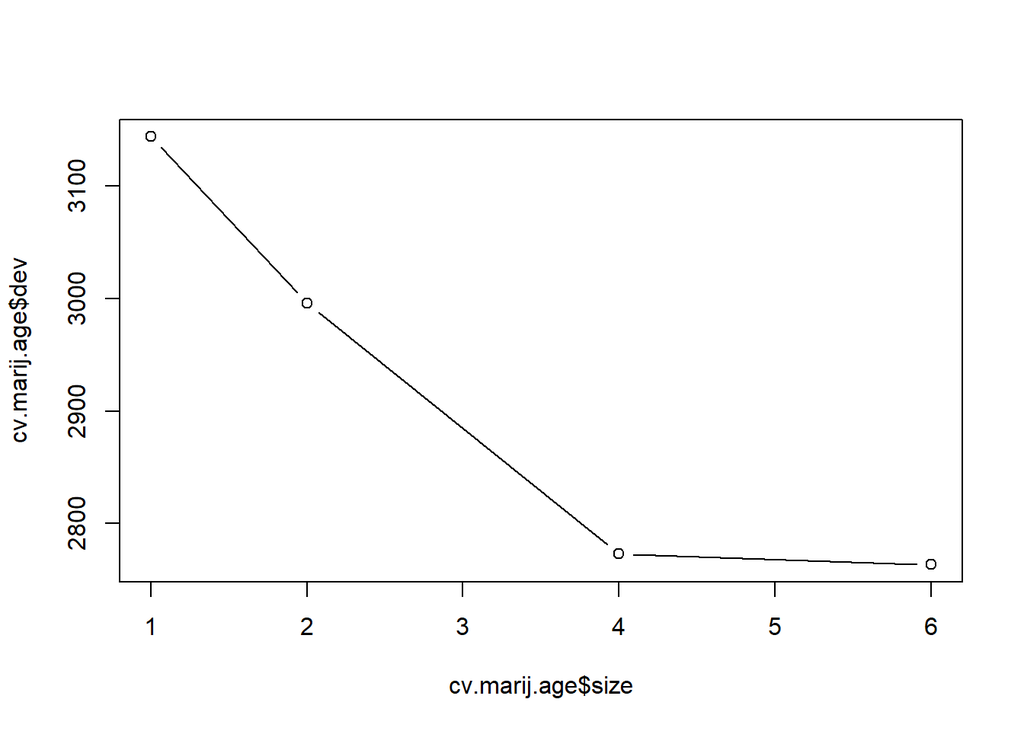

```r
plot(cv.marij.age$size, cv.marij.age$dev, type = "b")
```

The tree with the lowest cross-validation error is the most complex tree, with 6 terminal nodes. The decision tree we created already has 6 terminal nodes, so we don’t need to prune it.

Now let’s plot that tree:

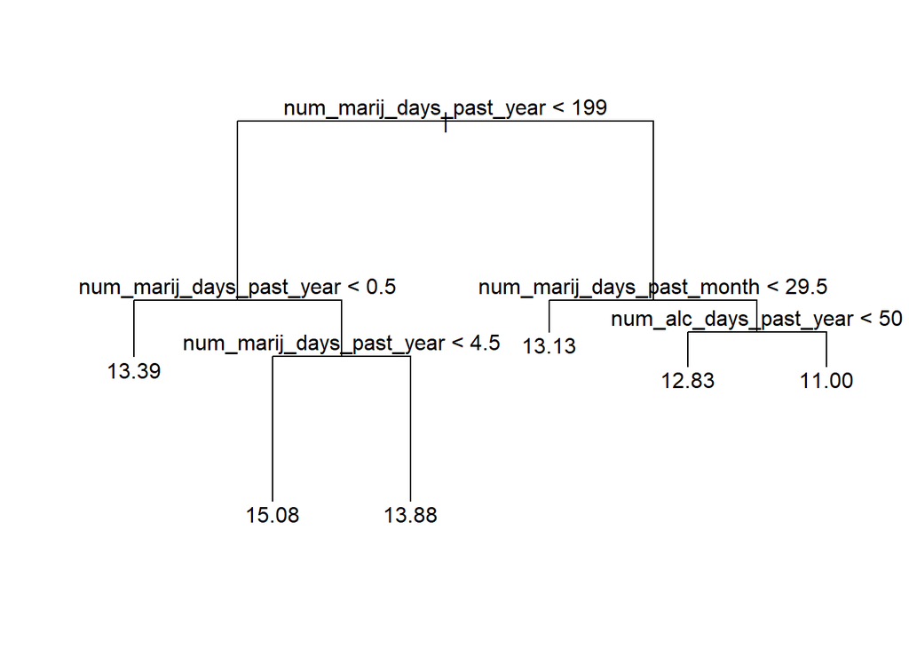

```r
plot(tree.marij.age)
text(tree.marij.age, pretty = 0)
```

The most important indicator of the age marijuana is first used, is the number of days marijuana was used in the past year, since that’s the first node in the decision tree.

On the left side of the tree, we see that, if a youth did not use marijuana at all this year, the predicted age of first marijuana use is 13.39. If a youth used marijuana for at least one day in the past year but at most 4 days, the predicted age of first use is 15.08. If a youth used marijuana for at least 5 days but fewer than 199 days, the predicted age is 13.88.

I was expecting that an increase in `num_marij_days_past_year` would cause either an increase or a decrease in the predicted age. Instead, on the left side of the tree (under 199 days of marijuana use), the predicted age starts at 13, then jumps up to 15, then goes back down to 13.

Now, on the right side, if the youth has used marijuana for at least 199 days in the past year, we look at the number of days they have used marijuana in the past month. These youth always have a lower first marijuana use age, even if it’s just slightly. If the number of marijuana use days per month is less than 30 (which is the highest possible value), then we predict an age of 13.13. If marijuana was used for all 30 days this month, however, we now look at the number of days the youth used alcohol this past year. If the youth has used alcohol for less than 50 days this year, we predict a first marijuana use age of 12.83, which is even lower. If the youth has used alcohol for at least 50 days, we predict a first marijuana use age of 11.00, which is drastically lower.

So, in summary, the model tells us that youth with a higher yearly marijuana use frequency have started using marijuana at earlier ages. The predicted age gets younger if the youth has used marijuana every day this month, and then gets younger again if they have used alcohol for at least 50 days this year. So, youth who use more yearly and monthly marijuana, and more alcohol, are predicted to have started using marijuana at younger ages. Youth who have used marijuana for 1-4 days this year, are predicted to have started using marijuana at the oldest age.

```r
marij.age.pred <- predict(tree.marij.age, newdata = youth.test.1) # Predicted age of first marijuana use in the test set
marij.age.test <- youth.test.1$first_marij_use_age # Actual age of first marijuana use in the test set
test.rmse <- sqrt( mean((marij.age.pred - marij.age.test)^2) ) # Take RMSE since it's in the same units as the response
test.rmse
```

```
## [1] 1.812089
```

The test RMSE for the regression tree is 1.81. So, on average, this model makes predictions that are within 1.81 years of the true age.

## Use bagging to predict the age of first alcohol use (regression)

```r
library(randomForest)
set.seed(1)

num.predictors <- ncol(youth.train.2) - 1 # Number of predictors in the dataset

bag.alc.age <- randomForest(first_alc_use_age ~ ., data = youth.train.2, mtry = num.predictors, importance = TRUE)
bag.alc.age
```

```
##
## Call:
##  randomForest(formula = first_alc_use_age ~ ., data = youth.train.2,      mtry = num.predictors, importance = TRUE)
##                Type of random forest: regression
##                      Number of trees: 500
## No. of variables tried at each split: 6
##
##           Mean of squared residuals: 5.648393
##                     % Var explained: -12.39
```

Before we compute the test RMSE, let’s find a suitable number of trees by plotting the number of trees vs. the error.

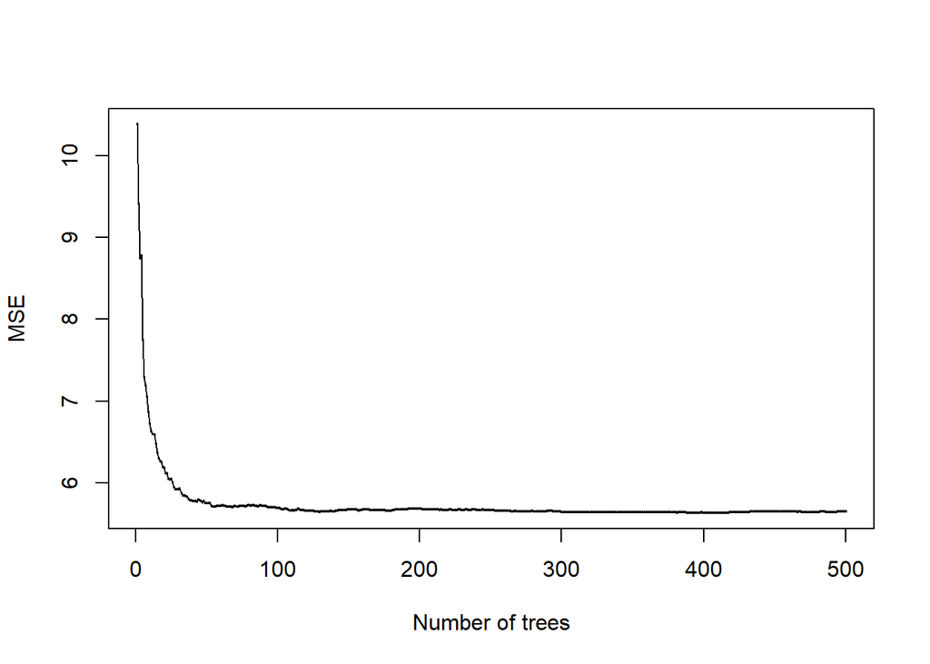

```r
plot(1:500, bag.alc.age$mse, type="o", xlab="Number of trees", ylab="MSE", cex=.2, lwd=1)
```

The error starts plateauing at about 100 trees. So, 100 trees is sufficient, and we don’t need 500. Let’s make a new bagged model with 100 trees:

```r
set.seed(1)

bag.alc.age <- randomForest(first_alc_use_age ~ ., data = youth.train.2, mtry = num.predictors, importance = TRUE, ntree=100)
bag.alc.age
```

```
##
## Call:
##  randomForest(formula = first_alc_use_age ~ ., data = youth.train.2,      mtry = num.predictors, importance = TRUE, ntree = 100)
##                Type of random forest: regression
##                      Number of trees: 100
## No. of variables tried at each split: 6
##
##           Mean of squared residuals: 5.691172
##                     % Var explained: -13.24
```

Now we’ll compute the test RMSE:

```r
alc.age.pred <- predict(bag.alc.age, newdata = youth.test.2)
alc.age.test <- youth.test.2$first_alc_use_age

test.rmse <- sqrt( mean((alc.age.pred - alc.age.test)^2) ) # Take RMSE since it's in the same units as the response
test.rmse
```

```
## [1] 2.485399
```

The test RMSE is 2.49, which means that, on average, this model makes predictions that are within 2.49 years of the true age that a youth started using alcohol. This is significantly worse than the test RMSE for the decision tree predicting the age of first marijuana use.

Now let’s look at variable importance:

```r
importance(bag.alc.age)
```

```
##                               %IncMSE IncNodePurity
## num_alc_days_past_year      10.612511     968.43328
## num_marij_days_past_year     7.509100    1135.51378
## num_cig_days_past_month      1.437284     179.39192
## num_tobacco_days_past_month -1.160806      51.07557
## num_alc_days_past_month      5.561684     387.79760
## num_marij_days_past_month    4.575043     551.72736
```

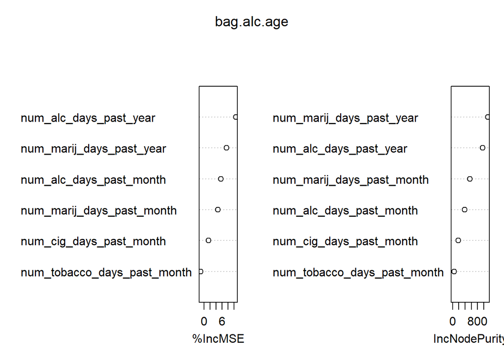

```r
varImpPlot(bag.alc.age)
```

The number of days of alcohol use this year and the number of days of marijuana use this year are the most important variables. This indicates that yearly drug use is more important than monthly drug use when predicting the age at which a person will start using alcohol. So, long-term drug use trends are more important than short-term trends.

## Use boosting to predict whether youth started using tobacco: 1. under 12 years old or 2. 12 and up, *or* never used tobacco

Below, we create a boosting model, while using the caret package to tune all the parameters for boosting.

```r
library(caret)
set.seed(1)

# Specify that we will do 10-fold CV for parameter tuning
train.control <- trainControl(method = "cv", number = 10)

# Grid of values for the parameters
grid <- expand.grid(interaction.depth = c(1, 2, 3, 4),
                    n.trees = c(10, 50, 100, 500, 1000),
                    shrinkage = c(0.001, 0.01, 0.1),
                    n.minobsinnode = 10)

# Do cross-validation
cv.out <- train(tobacco_age_class ~ .,
                data = youth.train.3,
                method = "gbm",
                trControl = train.control,
                distribution = "bernoulli",
                verbose = FALSE,
                tuneGrid = grid)
cv.out$bestTune # Get the chosen parameters
```

```
##   n.trees interaction.depth shrinkage n.minobsinnode
## 1      10                 1     0.001             10
```

The chosen set of parameters is `n.trees = 10`, `interaction.depth = 1`, and `shrinkage = 0.001`.

```r
# Get the boosting model
boost.tob.age <- cv.out$finalModel
```

### Model evaluation

First let’s look at the class distribution in the training and test sets:

```r
summary(youth.train.3$tobacco_age_class)
```

```
## 12+ or never used          Under 12
##               877                 8
```

```r
summary(youth.test.3$tobacco_age_class)
```

```
## 12+ or never used          Under 12
##               291                 3
```

The data is very imbalanced. In the training data, we have 877 samples in the “12+ or never used” class and only 8 in the “Under 12” class.

```r
tob.age.class.test <- youth.test.3$tobacco_age_class

# Need to convert the class labels in the test set to 0/1 to avoid errors
youth.test.3$tobacco_age_class <- ifelse(youth.test.3$tobacco_age_class == "Under 12", yes = 0, no = 1)

tob.pred.probs <- predict(boost.tob.age, youth.test.3, type = "response") # Predicted probabilities
```

```
## Using 10 trees...
```

```r
tob.age.class.pred <- ifelse(tob.pred.probs > 0.5, yes = "12+ or never used", no = "Under 12") # Convert these to class labels

table(Predicted = tob.age.class.pred, Actual = tob.age.class.test) # confusion matrix
```

```
##                    Actual
## Predicted           12+ or never used Under 12
##   12+ or never used               291        3
```

```r
# Overall prediction accuracy
overall.acc <- 291/nrow(youth.test.3)
overall.acc
```

```
## [1] 0.9897959
```

The confusion matrix indicates that all the samples in the test set were predicted as “12+ or never used”. None at all were predicted as “Under 12”. So, the class imbalance problem is especially severe here. This model performs very, very badly. It makes sense that the classifier is suffering from the class imbalance problem, since the training set was highly imbalanced. The test accuracy across all classes is approximately 99.0%. But that’s not a meaningful number at all because no samples in the minority class are classified correctly. If we passed in more samples from the minority class for test data, most of those would probably be misclassified as well.

I cannot directly compare this model with the previous ones, because those were for regression and this one was for classification. However, those performed reasonably well and this model performs very, very badly. I would be able to rely on insights those models, but definitely not this one.

### Relative influence

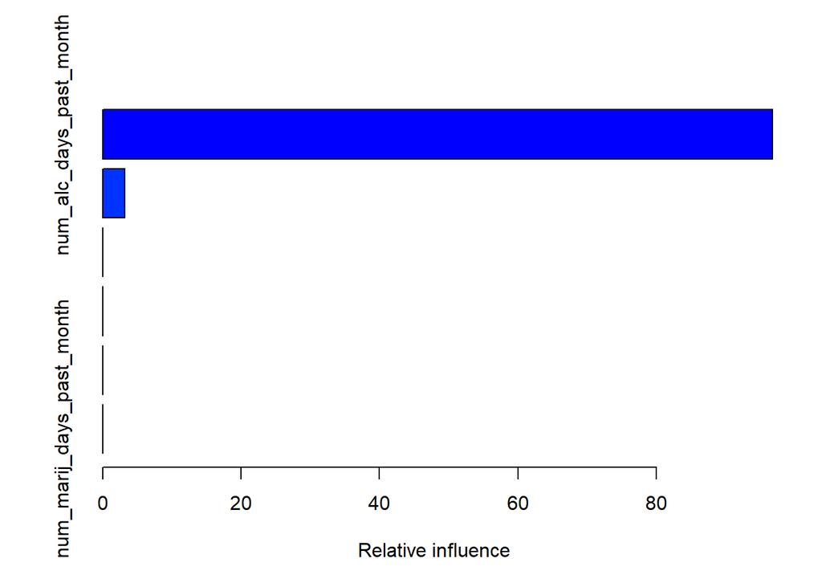

```
##                                                     var   rel.inf
## num_alc_days_past_month         num_alc_days_past_month 96.800032
## num_alc_days_past_year           num_alc_days_past_year  3.199968
## num_marij_days_past_year       num_marij_days_past_year  0.000000
## num_cig_days_past_month         num_cig_days_past_month  0.000000
## num_tobacco_days_past_month num_tobacco_days_past_month  0.000000
## num_marij_days_past_month     num_marij_days_past_month  0.000000
```

```r
summary(boost.tob.age)
```

4 of the 6 predictors used have a relative influence of exactly 0. So, those 4 variables are not important at all for predicting the age that a youth first used tobacco. The only variable that’s *very* important (with a relative influence of 96.8) is the number of days a youth has used alcohol in the past month. The other variable with nonzero relative influence is the number of days a youth used alcohol in the past year. But `num_alc_days_past_year` has a relative influence of only 3.2, which is tiny compared to the relative influence of `num_alc_days_past_month`. So, essentially, `num_alc_days_past_month` is the only important variable for predicting the age of first tobacco use.

This is surprising because I thought that the age of first tobacco use would be highly correlated with *current* tobacco use. But the opposite is true: current tobacco use is not important *at all* for predicting the age of first use.

However, this model performs very badly because it suffers heavily from the class imbalance problem. So, we cannot really trust this model for saying anything useful about the data. Perhaps we would have different relative influences if the classes were more balanced.

### Partial dependence plots

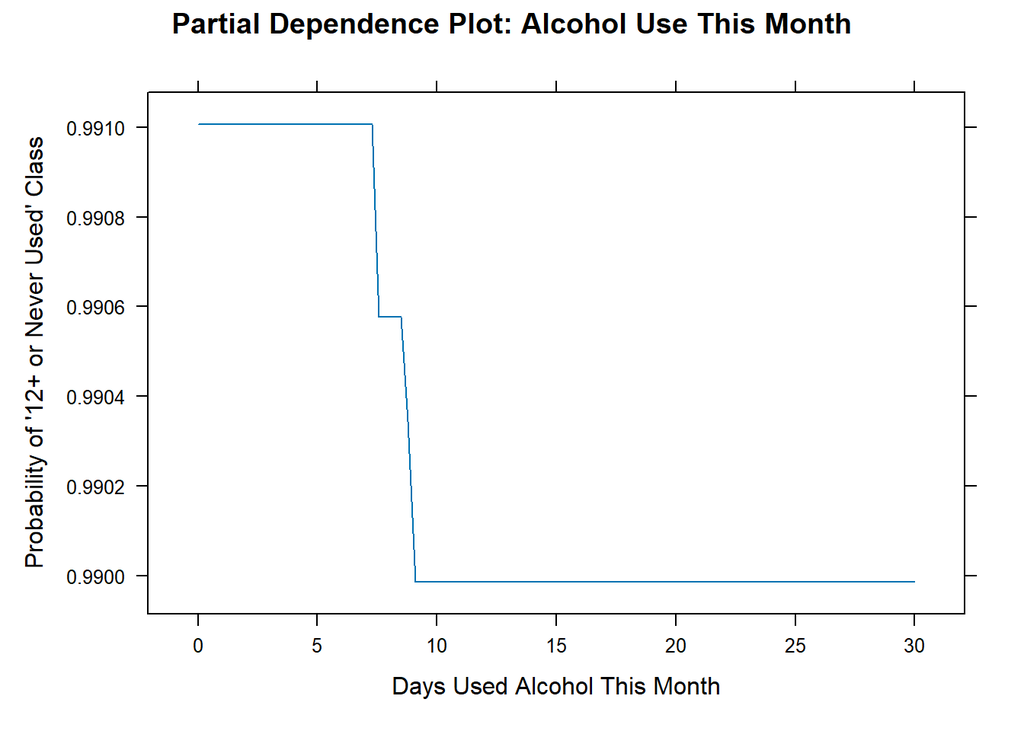

```r
plot(boost.tob.age, i = "num_alc_days_past_month", type = "response", xlab = "Days Used Alcohol This Month", ylab = "Probability of '12+ or Never Used' Class", main = "Partial Dependence Plot: Alcohol Use This Month")
```

Above, the y-axis represents the *probability* that the class label is “12+ or never used”. If the probability is greater than 0.5, then “12+ or never used” is the predicted class. The plot shows that all the predicted probabilities are very high, at least 99%. That agrees with our model results, where the class imbalance was so high that the model only predicted “12+ or never used” for the entire test set. If the model only predicts one class, it makes sense that that class would have a very high probability. So, even though the monthly alcohol frequency is the only important variable, this plot is not really telling us anything because all the probabilities are very high. It’s only saying “We predict ‘12+ or never used’ every time, with almost complete certainty”.

But let’s try to interpret the plot anyway. If we are paying attention to *very small* changes, then the probability of “12+ or never used” decreases as the alcohol use increases. So, youth who are more likely to have first used tobacco under age 12, currently use alcohol more. There is a sharp decrease in probability at approximately 7 days of alcohol use, and there is another sharp decrease at approximately 9 days of alcohol use. Thus, youth who use alcohol for 7 or less days a month, are more likely to have first used tobacco above age 12 *or* to have never used tobacco. Youth who use alcohol for 9 or more days a month, are more likely to have first used tobacco under 12. So, youth who use more alcohol now (monthly) are more likely to have started using tobacco at younger ages. However, the plot shows a change in probability of 0.001 at most. So, these effects are so small that they are basically nonexistent.

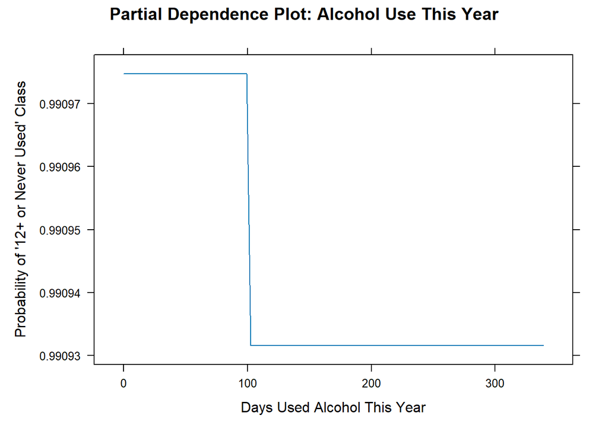

```r
plot(boost.tob.age, i = "num_alc_days_past_year", type = "response", xlab = "Days Used Alcohol This Year", ylab = "Probability of '12+ or Never Used' Class", main = "Partial Dependence Plot: Alcohol Use This Year")
```

Again, the y-axis represents the probability that the class label is “12+ or never used”. Again, all the predicted probabilities are above 99%, and that agrees with the bad model results. This time, the change in probability across the entire plot is even smaller: it’s 4 x 10^(-5). So, the effects of the yearly alcohol use variable are even less significant than the monthly one! That makes sense because the relative influence of this variable was very small compared to the monthly alcohol use variable. So, this plot is meaningless as well.

Still, let’s interpret the plot as if the changes in probability were meaningful. There is a sharp decrease at about 100 days of alcohol use. So, youth who use more than 100 days of alcohol a year, are more likely to have started using tobacco at earlier ages.

If both plots were meaningful, then youth who use more alcohol right now, are more likely to have a younger first age of tobacco use. And monthly alcohol use causes a greater potential change in predictions than yearly alcohol use. However, both of these “changes” are basically nonexistent.

## Use a random forest to predict the age group in which youth started using cigarettes

We have a categorical variable for the age group that a youth was in when they started using cigarettes. The categories are “Under 12”, “12-13”, “14-17”, and “Never used”. So, this is a multiclass classification problem.

```r
set.seed(1)

rf.cig.age <- randomForest(cig_age_class ~ ., data = youth.train.4, importance = TRUE)
```

### Find the appropriate number of trees:

```r
# These are the first 10 training error rates, and the ith element is "the (OOB) error rate for all trees up to the i-th" (R Documentation)
rf.cig.age$err.rate[1:10,]
```

```
##             OOB     12-13     14-17 Never used  Under 12
##  [1,] 0.4440994 1.0000000 0.7758621  0.1510417 0.9166667
##  [2,] 0.4593573 0.9830508 0.7924528  0.1725240 0.9215686
##  [3,] 0.4690799 0.9701493 0.7573529  0.2070707 0.9531250
##  [4,] 0.4618474 0.9740260 0.7346939  0.2062084 0.9583333
##  [5,] 0.4629862 0.9662921 0.7354839  0.2000000 0.9487179
##  [6,] 0.4605263 0.9587629 0.7283951  0.1955645 0.9506173
##  [7,] 0.4592075 0.9313725 0.7696970  0.1791339 0.9759036
##  [8,] 0.4561201 0.9619048 0.7650602  0.1647059 0.9764706
##  [9,] 0.4440639 0.9142857 0.7604790  0.1583012 0.9767442
## [10,] 0.4375000 0.9238095 0.7261905  0.1557692 0.9770115
```

```r
rf.cig.age$err.rate[1:10,1] # These are the first 10 OOB error rate for all the classes
```

```
##  [1] 0.4440994 0.4593573 0.4690799 0.4618474 0.4629862 0.4605263 0.4592075
##  [8] 0.4561201 0.4440639 0.4375000
```

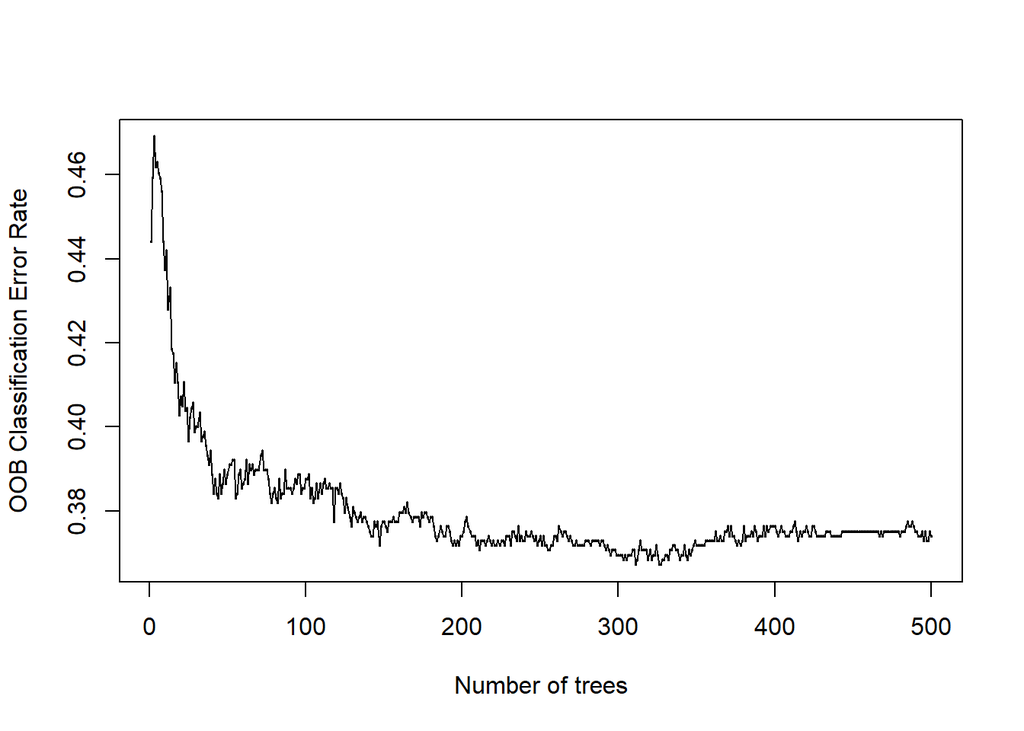

```r
plot(1:500, rf.cig.age$err.rate[,1], type="o", xlab="Number of trees", ylab="OOB Classification Error Rate", cex=.2, lwd=1)
```

The training error generally plateaus at about 250 trees. The error does slightly fluctuate up and down after it plateaus, but those fluctuations are small, and the general trend is a plateau after approximately 250 trees. So, we will use a random forest with 250 trees.

### Find the best number of predictors

We will tune `mtry`, the number of predictors that can be considered in each decision tree split.

```
## mtry = 2  OOB error = 37.29%
## Searching left ...
## mtry = 1     OOB error = 36.05%
## 0.03333333 0.05
## Searching right ...
## mtry = 4     OOB error = 42.71%
## -0.1454545 0.05
```

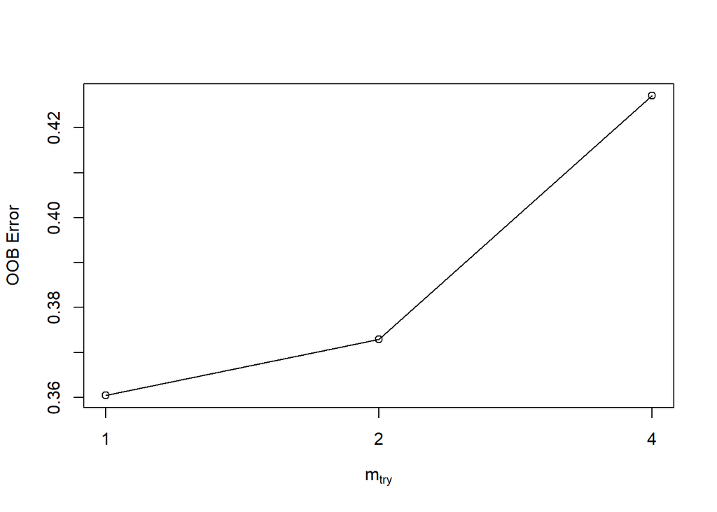

```r
# Use the tuneRF() function to do cross-validation for the number of predictors used in each split
set.seed(1)

y.train.4 <- youth.train.4$cig_age_class # The response variable
x.train.4 <- youth.train.4[, 1:6]        # The matrix of predictors

# Use 250 trees. Return a matrix containing the mtry values and the corresponding OOB error
tune.out <- tuneRF(x = x.train.4, y = y.train.4, ntreeTry = 250, trace = TRUE, plot = TRUE, doBest=FALSE)
```

```r
tune.out
```

```
##       mtry  OOBError
## 1.OOB    1 0.3604520
## 2.OOB    2 0.3728814
## 4.OOB    4 0.4271186
```

Using `mtry = 1` (one predictor considered at each split) gives the best OOB error.

### Create and evaluate the model

Now let’s create a model with the tuning parameters we found and use it to get the classification error on the training and test set:

```r
set.seed(1)

rf.cig.age <- randomForest(cig_age_class ~ ., data = youth.train.4, ntree=250, mtry=1, importance = TRUE)
rf.cig.age
```

```
##
## Call:
##  randomForest(formula = cig_age_class ~ ., data = youth.train.4,      ntree = 250, mtry = 1, importance = TRUE)
##                Type of random forest: classification
##                      Number of trees: 250
## No. of variables tried at each split: 1
##
##         OOB estimate of  error rate: 36.16%
## Confusion matrix:
##            12-13 14-17 Never used Under 12 class.error
## 12-13          1    14         88        2 0.990476190
## 14-17          1    44        126        0 0.742690058
## Never used     1     2        519        0 0.005747126
## Under 12       1    19         66        1 0.988505747
```

Let’s look at the class distribution of the training data:

```r
summary(youth.train.4$cig_age_class)
```

```
##      12-13      14-17 Never used   Under 12
##        105        171        522         87
```

There is also a class imbalance in this data, but it’s not as severe as for the tobacco classification problem. Most youth have never used cigarettes. Of those who have used cigarettes, most youth started using them at age 14-17. A smaller number of youth started using them at 12-13, and the smallest number of youth started using them under 12.

In the training set, only 1 youth in the “12-13” class and 1 youth in the “Under 12” class were classified correctly, respectively. On the training data, the random forest classifies “Never used” the best, which makes sense because that’s the majority class. It classifies “14-17” the second-best, and it classifies the other classes very poorly. That’s exactly consistent with the class distribution in the training set.

The OOB error is very high, 36.16%. That is probably because the class imbalance here is less severe than the class imbalance for tobacco use. But also, this model still predicts the majority class much more accurately than the other classes. So, if the other classes have *more* samples but are being predicted *incorrectly*, that would cause the classification error to be high.

Let’s look at the class distribution in the test set:

```r
summary(youth.test.4$cig_age_class)
```

```
##      12-13      14-17 Never used   Under 12
##         35         62        172         25
```

The distribution of classes in the test set is as unbalanced as in the training set.

```r
cig.age.class.pred <- predict(rf.cig.age, youth.test.4)
cig.age.class.test <- youth.test.4$cig_age_class

table(Predicted = cig.age.class.pred, Actual = cig.age.class.test) # confusion matrix
```

```
##             Actual
## Predicted    12-13 14-17 Never used Under 12
##   12-13          0     1          0        0
##   14-17          5    17          0        3
##   Never used    27    43        172       22
##   Under 12       3     1          0        0
```

```r
accuracy.14.17 <- 17/62 # Find the test accuracy for the 14-17 class
accuracy.14.17
```

```
## [1] 0.2741935
```

```r
overall.acc <- (17+172)/nrow(youth.test.4)
overall.acc
```

```
## [1] 0.6428571
```

For the test set, the random forest classifies “Never used” 100% accurately. However, it has 0% accuracy for “12-13” and “Under 12”. The “14-17” class is predicted with 27.4% accuracy. Many of the observations that are not in “Never used” are predicted as “Never used”, which makes sense because that’s the majority class. Like the model for tobacco use, this is a bad, unreliable model because the class imbalance caused bias toward the majority class. This model even predicted the smallest two classes with 0% accuracy, similarly to the boosting model.

The accuracy across all the classes is 64.2%. That indicates that, even though we predict “Never used” perfectly, the inaccurate predictions for all the other classes contribute a lot to the overall classification error. This makes sense because the classes are not as imbalanced as in the last problem.

Unlike the model for tobacco, this model predicts all 4 classes at least sometimes. The other model *only* predicted the majority class for every test sample, and never the minority class. So, at least the accuracy per each class is a metric that exists for this model, unlike that one. That makes this model an improvement from the model for tobacco. However, “improvement” is not saying much because both models perform very badly. Also, this model predicts one of the non-majority classes (“14-17”) with 27% accuracy. That’s much better than the tobacco model, which couldn’t predict the minority class at all. The reason this model performs better is that the class imbalance is less severe.

Note that, although there are parallels between the two models, we cannot quite directly compare a binary classification model with a multiclass one. I cannot directly compare this classification model with the regression ones either. But, again, the regression models performed fairly well and this one performs very badly. I would trust those models, but not this one.

### Variable importance

```r
importance(rf.cig.age)
```

```
##                                  12-13      14-17 Never used   Under 12
## num_alc_days_past_year      -0.3810802  3.9646504   3.882624 -0.3640629
## num_marij_days_past_year    -1.8532640 -0.4334362   9.550985  1.9089485
## num_cig_days_past_month      4.1373670 19.3184021  29.032560  8.2715083
## num_tobacco_days_past_month  7.5131746  1.1815784   3.152804 -1.7657627
## num_alc_days_past_month     -0.4936412  1.4520828   5.590923  0.9858321
## num_marij_days_past_month   -1.7182949 -2.5114245   9.189214 -2.7705257
##                             MeanDecreaseAccuracy MeanDecreaseGini
## num_alc_days_past_year                  5.067291        26.635881
## num_marij_days_past_year                9.702344        27.077393
## num_cig_days_past_month                29.729413        36.442409
## num_tobacco_days_past_month             5.618605         5.563554
## num_alc_days_past_month                 6.561089        17.400350
## num_marij_days_past_month               8.159103        17.879107
```

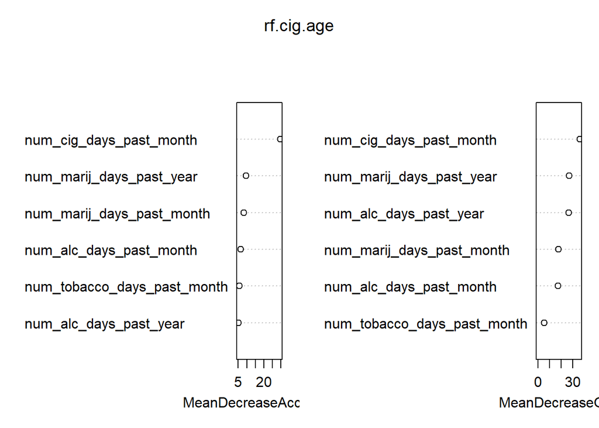

```r
varImpPlot(rf.cig.age)
```

The most important variable, by a lot, is `num_cig_days_past_month`. So, age of first cigarette use is highly dependent on current monthly cigarette use. There is a strong relationship between age of first cigarette use and current cigarette use. Also, the mean decrease in accuracy for `num_cig_days_past_month` is 29.7%, which is much higher than the mean decrease in accuracy for the other variables. So, using only mean decrease in accuracy as a measure, current monthly cigarette use is way more impactful than the other variables for predicting the age of first cigarette use.

The second most important variable, by both metrics, is the number of days the youth has used marijuana in the past year. So, there is also a strong relationship between age of first cigarette use and current marijuana use.

However, we cannot truly rely on any insights from this model. It’s unreliable because of class imbalance, and if the classes were more balanced, perhaps the variable importance results would be different.